# Synthetic Control-CA Tobacco

YC

2024-06-23

## Synthetic Control tutorial

This tutorial aims to reproduce the results of Abadie et al. 2010, which evaluates the impact of Proposition 99 on cigarette consumption in California. This tutorial will use the `Synth` package in R, which implements synthetic control methods used in comparative case studies. These methods construct a synthetic control unit as weighted average of available control units that best approximate the relevant characteristics of the treated unit prior to the treatment.

```r
library(tidyverse)
library(skimr)
library(Synth)
library(SCtools)
library(rio)
```

## Data

Read in the [smoking example dataset](https://github.com/edunford/tidysynth/tree/master/data)

```r
dt_smoke = import("./data/smoking.rda")
```

### Data exploration

```r
glimpse(dt_smoke)
```

```
## Rows: 1,209
## Columns: 7
## $ state     <chr> "Rhode Island", "Tennessee", "Indiana", "Nevada", "Louisiana…
## $ year      <dbl> 1970, 1970, 1970, 1970, 1970, 1970, 1970, 1970, 1970, 1970, …
## $ cigsale   <dbl> 123.9, 99.8, 134.6, 189.5, 115.9, 108.4, 265.7, 93.8, 100.3,…
## $ lnincome  <dbl> NA, NA, NA, NA, NA, NA, NA, NA, NA, NA, NA, NA, NA, NA, NA, …
## $ beer      <dbl> NA, NA, NA, NA, NA, NA, NA, NA, NA, NA, NA, NA, NA, NA, NA, …
## $ age15to24 <dbl> 0.1831579, 0.1780438, 0.1765159, 0.1615542, 0.1851852, 0.175…
## $ retprice  <dbl> 39.3, 39.9, 30.6, 38.9, 34.3, 38.4, 31.4, 37.3, 36.7, 28.8, …
```

```r
skim(dt_smoke)
```

Data summary

| Name | dt_smoke |
| --- | --- |
| Number of rows | 1209 |
| Number of columns | 7 |
| _______________________ |  |
| Column type frequency: |  |
| character | 1 |
| numeric | 6 |
| ________________________ |  |
| Group variables | None |

**Variable type: character**

| skim_variable | n_missing | complete_rate | min | max | empty | n_unique | whitespace |
| --- | --- | --- | --- | --- | --- | --- | --- |
| state | 0 | 1 | 4 | 14 | 0 | 39 | 0 |

**Variable type: numeric**

| skim_variable | n_missing | complete_rate | mean | sd | p0 | p25 | p50 | p75 | p100 | hist |
| --- | --- | --- | --- | --- | --- | --- | --- | --- | --- | --- |
| year | 0 | 1.00 | 1985.00 | 8.95 | 1970.00 | 1977.00 | 1985.00 | 1993.00 | 2000.00 | ▇▇▇▇▇ |
| cigsale | 0 | 1.00 | 118.89 | 32.77 | 40.70 | 100.90 | 116.30 | 130.50 | 296.20 | ▂▇▁▁▁ |
| lnincome | 195 | 0.84 | 9.86 | 0.17 | 9.40 | 9.74 | 9.86 | 9.97 | 10.49 | ▂▇▇▂▁ |
| beer | 663 | 0.45 | 23.43 | 4.22 | 2.50 | 20.90 | 23.30 | 25.10 | 40.40 | ▁▁▇▂▁ |
| age15to24 | 390 | 0.68 | 0.18 | 0.02 | 0.13 | 0.17 | 0.18 | 0.19 | 0.20 | ▁▂▅▇▃ |
| retprice | 0 | 1.00 | 108.34 | 64.38 | 27.30 | 50.00 | 95.50 | 158.40 | 351.20 | ▇▅▃▁▁ |

### Prep the data

```r
dt_smoke$st = as.numeric(as.factor(dt_smoke$state))
ctr_doners = unique(dt_smoke$st)
ctr_doners = ctr_doners[ctr_doners != 3]


smoke_out = dataprep(
  foo = dt_smoke,  # dataset to be prepared

  predictors = c("lnincome", "retprice", "age15to24"),
  predictors.op = "mean", # operation on the predictors
  time.predictors.prior = 1980:1988,

  # Special predictors with repective time periods and operations
  special.predictors = list(
    list("beer", 1984:1988, "mean"),
    list("cigsale", 1975, "mean"),
    list("cigsale", 1980, "mean"),
    list("cigsale", 1988, "mean")
  ),

  dependent = "cigsale",
  unit.variable = "st",
  unit.names.variable = "state",

  time.variable = "year",
  treatment.identifier = 3,
  controls.identifier = ctr_doners,

  time.optimize.ssr = 1970:1988,
  time.plot = 1970:2000

)
```

```r
# Treatment unit predictors
smoke_out$X1
```

```
##                                  3
## lnincome                10.0765586
## retprice                89.4222234
## age15to24                0.1735324
## special.beer.1984.1988  24.2800003
## special.cigsale.1975   127.0999985
## special.cigsale.1980   120.1999969
## special.cigsale.1988    90.0999985
```

```r
# Outcome variables BEFORE treatment
smoke_out$Z1
```

```
##          3
## 1970 123.0
## 1971 121.0
## 1972 123.5
## 1973 124.4
## 1974 126.7
## 1975 127.1
## 1976 128.0
## 1977 126.4
## 1978 126.1
## 1979 121.9
## 1980 120.2
## 1981 118.6
## 1982 115.4
## 1983 110.8
## 1984 104.8
## 1985 102.8
## 1986  99.7
## 1987  97.5
## 1988  90.1
```

## Running the model

To get the optimal weights

```r
 synth_out = synth(data.prep.obj = smoke_out,
                    method = "BFGS" #   set optim() to use the BFGS quasi-Newton algorithm.
                    )
```

```
##
## X1, X0, Z1, Z0 all come directly from dataprep object.
##
##
## ****************
##  searching for synthetic control unit
##
##
## ****************
## ****************
## ****************
##
## MSPE (LOSS V): 3.209078
##
## solution.v:
##  0.0005834245 0.03117412 0.003366973 0.01243231 0.4925228 0.3917451 0.06817527
##
## solution.w:
##  1.54276e-05 1.27942e-05 0.1746846 0.06241991 1.58974e-05 1.6702e-05 0.0005198364 5.23691e-05 1.70182e-05 3.50418e-05 3.29134e-05 6.2085e-06 1.28701e-05 1.56504e-05 0.0003307624 1.35409e-05 1.89209e-05 0.1819706 0.0001088187 0.2357516 4.9e-09 0.0003359019 8.077e-06 7.8715e-06 2.06963e-05 9.3329e-…
```

## Results

Compares pre-treatment predictor values for the treated unit, the synthetic control unit, and all the units in the sample.

```r
synth_tables = synth.tab(dataprep.res = smoke_out,
                           synth.res    = synth_out
                           )
synth_tables$tab.pred
```

```
##                        Treated Synthetic Sample Mean
## lnincome                10.077     9.859       9.829
## retprice                89.422    89.318      87.266
## age15to24                0.174     0.174       0.173
## special.beer.1984.1988  24.280    24.095      23.655
## special.cigsale.1975   127.100   126.897     136.932
## special.cigsale.1980   120.200   120.248     138.089
## special.cigsale.1988    90.100    91.432     113.824
```

The weight corresponding to each predictor

```r
synth_tables$tab.v
```

```
##                        v.weights
## lnincome               0.001
## retprice               0.031
## age15to24              0.003
## special.beer.1984.1988 0.012
## special.cigsale.1975   0.493
## special.cigsale.1980   0.392
## special.cigsale.1988   0.068
```

The weight corresponding to each potential control unit

```r
synth_tables$tab.w
```

```
##    w.weights     unit.names unit.numbers
## 1      0.000   Rhode Island           29
## 2      0.000      Tennessee           32
## 4      0.175        Indiana           10
## 5      0.062         Nevada           21
## 6      0.000      Louisiana           14
## 7      0.000       Oklahoma           27
## 8      0.001  New Hampshire           22
## 9      0.000   North Dakota           25
## 10     0.000       Arkansas            2
## 11     0.000       Virginia           36
## 12     0.000       Illinois            9
## 13     0.000   South Dakota           31
## 14     0.000           Utah           34
## 15     0.000        Georgia            7
```

[output cut: 24 more lines]

### Plot

Treatment vs synthetic control

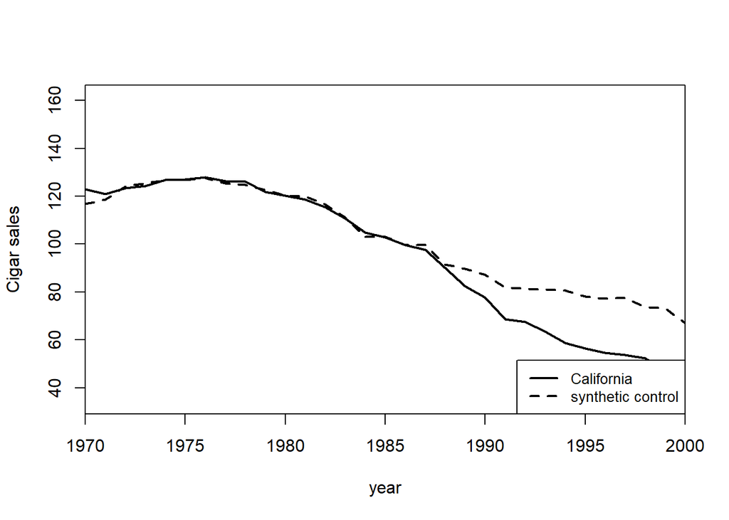

```r
path.plot(synth.res = synth_out,
           dataprep.res = smoke_out,
           Ylab = "Cigar sales",
           Xlab = "year",
           Legend = c("California","synthetic control"),
           Legend.position = "bottomright"
           )
```

Gaps plot

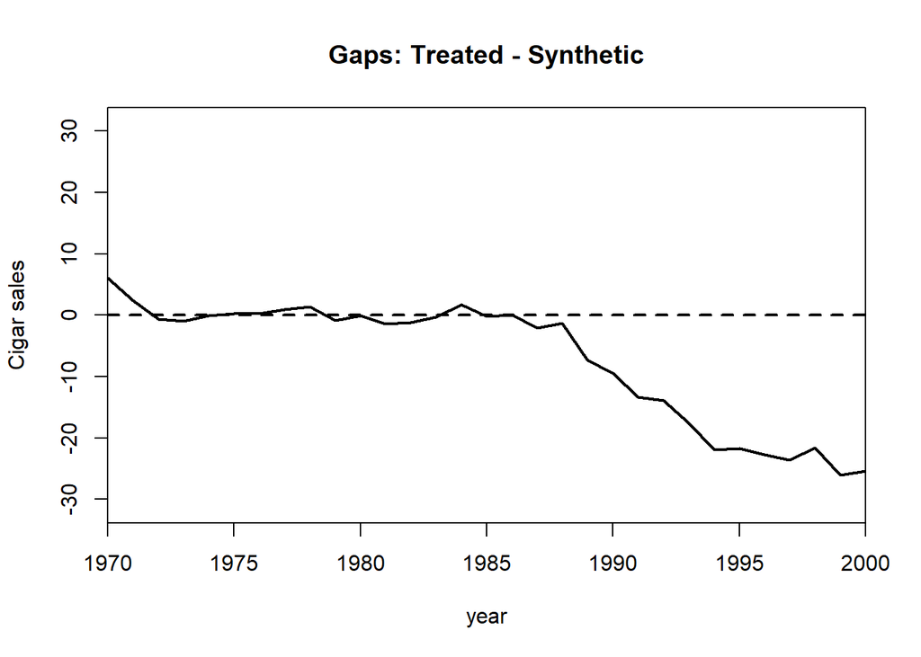

```r
gaps.plot(synth.res = synth_out,
           dataprep.res = smoke_out,
           Ylab = "Cigar sales",
           Xlab = "year"
           )
```

### References

Abadie, A., Diamond, A., & Hainmueller, J. (2010). Synthetic Control Methods for Comparative Case Studies: Estimating the Effect of California’s Tobacco Control Program. Journal of the American Statistical Association, 105(490), 493–505. https://doi.org/10.1198/jasa.2009.ap08746